Appendix C to the 2015 Georgia Milestones Growth Model Report:

Investigation of Potential Ceiling and Floor Effects.

Adam R. VanIwaarden

Damian W. Betebenner

National Center for the Improvement  
of Educational Assessment (NCIEA)

April 2016

# 1 Introduction

In the 2014-2015 academic year Georgia transitioned from its previous assessment program, the Criterion-Referenced Competency Tests (CRCT), to the [Georgia Milestones Assessment System.](http://www.gadoe.org/Curriculum-Instruction-and-Assessment/Assessment/Pages/Georgia-Milestones-Assessment-System.aspx) The transition included numerous changes to the assessment system including the incorporation of new performance standards. As other states have gone through similar assessment transitions, many have observed ceiling and floor effects in the new assessments (i.e. a relatively large proportion of students scoring at/near the scale extremes). This has occurred despite purported improvements in assessment qualities that should prevent these effects (e.g. adaptive tests). Regardless of the source of assessment ceilings/floors, they can telegraph onto the Student Growth Percentile (SGP) calculations making these estimates questionable.

Although very similar in nature, ceiling effects are somewhat more problematic than floor effects because students that consistently achieve the highest scores receive lower than expected growth percentiles and are therefore negatively impacted. Conversely, the consistently lowest achieving students have higher estimated SGPs than would be expected. Although this could be interpreted as a positive impact for these students by giving them higher SGPs, it can also conceal unacceptably low growth that needs to be identified and addressed.

Essentially these problems are caused by the way in which a “percentile” is most typically defined to begin with, and the inability of the assessments (and therefore the SGP model) to make granular distinctions between kids who score at the extremes of the test year after year. As an example, if a group of students were tested with a relatively easy test and 20% of the students had a perfect score, these students would be defined as being in the 80<sup>th</sup> percentile because they scored higher than 80% of their peers. This is somewhat misleading however, because their score was *equal to* or greater than *all* of their peers and so could be also described as achieving at the 99<sup>th</sup> percentile under an equally valid definition.

To extend this heuristic from achievement to growth, if 50% of those top students also scored perfectly on the next test, we might estimate that they had 50<sup>th</sup> percentile growth. Although there is nothing *technically* incorrect about this estimate since their growth is fairly typical for their academic peer group, it is an inadequate or unsatisfactory assessment of their growth because they have consistently attained at the highest observable level. Furthermore, if it is typical for their peers to maintain perfect scores then even small deviations from a perfect score could produce *low growth* SGP estimates. Ideally, the expectation is that the majority of SGPs for students scoring at or near the lowest obtainable scale score (LOSS) will be low (preferably less than 5 and not higher than 10), and that SGPs for students with the highest obtainable scale score (HOSS) will be high (higher than 95 and not less than 90).

Given these impacts and the difficulty in detecting them using traditional SGP diagnostic tools, the Center for Assessment has added “Ceiling/Test Effects” indicators to the SGP model goodness of fit plots and is providing all clients even more rigorous diagnostic and descriptive analyses through this Appendix to the annual technical report. This report includes:

1. Plots of the scale score distributions for the current and prior years’ tests, which may provide an indication of whether a ceiling or floor is present in either (or both) the current or historical data.
2. Box plots showing the range and distribution of SGPs for *only* the highest and lowest achieving students in the current year.

# 2 Prior and Current Year Score Distributions

The marginal and conditional distributions of scale scores can serve as a preliminary indicator of potential ceiling or floor effects in the calculation of student growth percentiles. Some minor problems could present themselves if these characteristics are present in either prior or current year scores, and are particularly likely when present in both. The plots below depict distributions for the current year and the most recent prior year used in the SGP calculations. The marginal (individual or univariate) distributions for each year are shown in the first subsections below, followed by the conditional (joint) distributions.

## 2.1 Marginal Distributions

Generally there is little evidence of potential issues with the Georgia tests in either the prior (2014 CRCT, shown in blue) and current (2015 Milestones, shown in red) end of grade (EOG) test scale scores. There are some indications of potential minor ceiling effects in the 2014 CRCT assessments, particularly the Reading data. These appear as spikes in the distributions at the extremes. The 2015 Milestones distributions are not concerning (although the tails of the distributions are long). This conforms to what was first observed in the SGP model goodness of fit plots (see 2015 technical report Appendix A), and conditional density and SGP distribution box plots in subsequent sections of this Appendix.

### 2.1.1 ELA

##### **Fig. C.1:** Marginal distributions of prior scale scores: CRCT Reading.

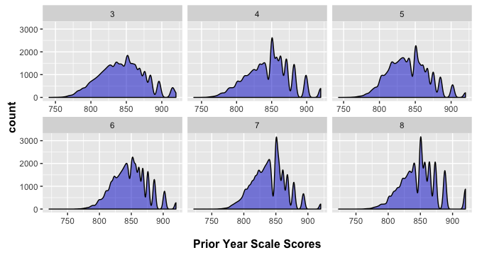

##### **Fig. C.2:** Marginal distributions of prior scale scores: CRCT ELA.

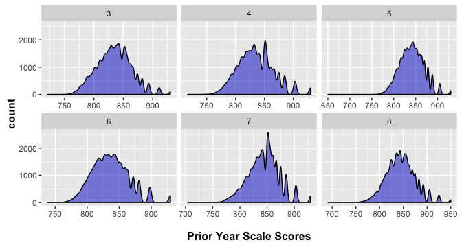

##### **Fig. C.3:** Marginal distributions of current scale scores: EOG ELA.

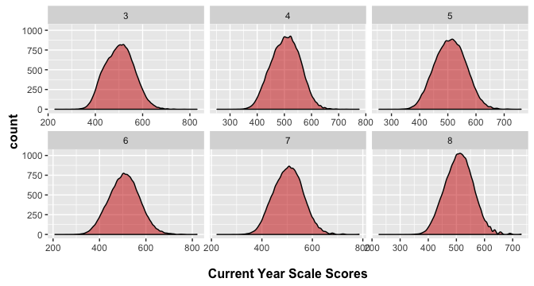

### 2.1.2 Social Studies

##### **Fig. C.4:** Marginal distributions of prior scale scores: CRCT Social Studies.

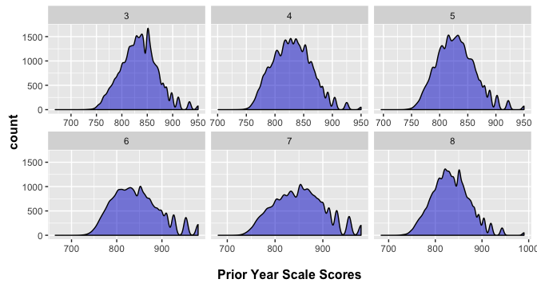

##### **Fig. C.5:** Marginal distributions of current scale scores: EOG Social Studies.

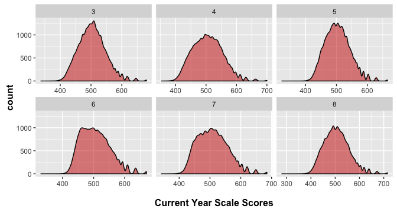

### 2.1.3 Science

##### **Fig. C.6:** Marginal distributions of prior scale scores: CRCT Science.

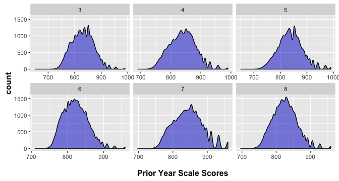

##### **Fig. C.7:** Marginal distributions of current scale scores: EOG Science.

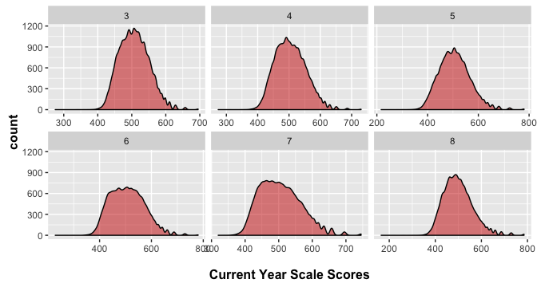

### 2.1.4 Mathematics

##### **Fig. C.8:** Marginal distributions of prior scale scores: CRCT Mathematics.

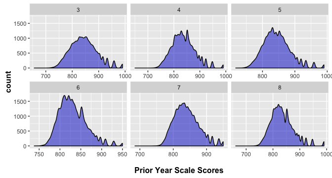

##### **Fig. C.9:** Marginal distributions of current scale scores: EOG Mathematics.

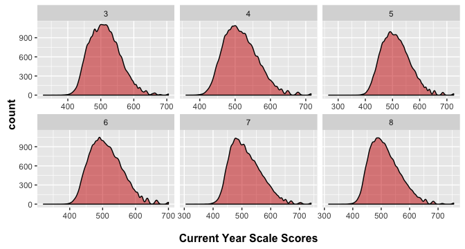

### 2.1.5 End-of-Course Test Subjects

##### **Fig. C.10:** Marginal distributions of prior scale scores: End-of-Course Subjects.

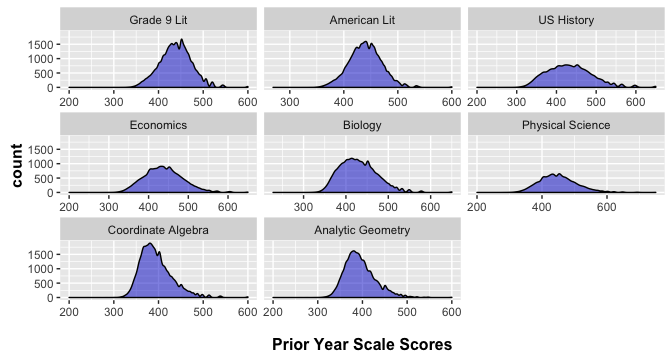

##### **Fig. C.11:** Marginal distributions of current scale scores: End-of-Course Subjects.

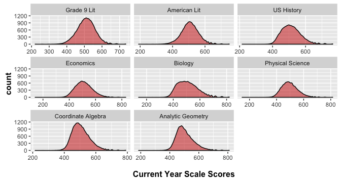

## 2.2 Conditional Distributions

The marginal density plots provide a limited amount of information, particularly for the potential for ceiling/floor effects in the calculation of *growth*. In order to provide a more nuanced view of the relationship between the prior and current scale scores, the following plots depict the conditional (joint) distributions for each content area and grade level. These plots start with a basic scatter plot of each student’s scores, and on top of this is layered 1) **green contour lines** to provide a sense of the joint density, 2) a **magenta non-linear line** identifying the bivariate relationship between prior and current scores, and 3) **rug plots** that describe the marginal distributions (as above, the prior scores are blue and current scores are red).

Ceiling or floor effects can appear as dark shaded points in the extreme top-right or bottom-left corners of the plots. This suggests that staying at the extremes from year to year is not uncommon, which may lead to odd growth estimates for these chronically high/low achieving students. For the 2014 and 2015 Georgia data, we again see very few issues in all content area and grade combinations. Where minor ceiling/floor effects appear in the prior year (CRCT) data, the 2015 score distributions for these students are well distributed. That is, in plots in which a minor shaded point in the upper right corners are present the other students who scored at the HOSS on the 2014 CRCT tests had a wide range if Milestones scores, which lessens the concern for a ceiling effect in most cases.

### 2.2.1 End-of-Grade Content Areas

##### **Fig. C.12:** Conditional distribution(s) of current and prior scale scores: ELA.

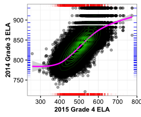

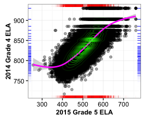

##### **Fig. C.13:** Conditional distribution(s) of current and prior scale scores: ELA *Continued*.

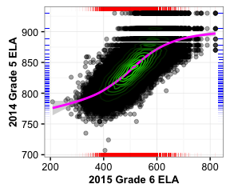

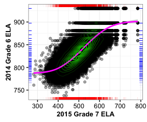

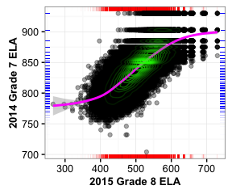

##### **Fig. C.14:** Conditional distribution(s) of current and prior scale scores: Social Studies.

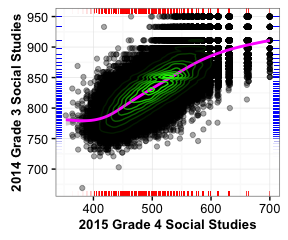

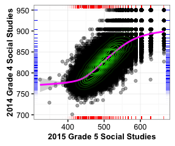

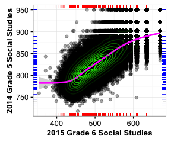

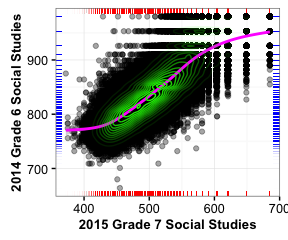

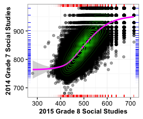

##### **Fig. C.15:** Conditional distribution(s) of current and prior scale scores: Science.

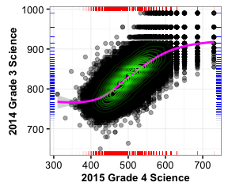

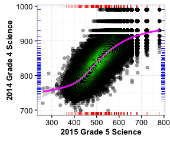

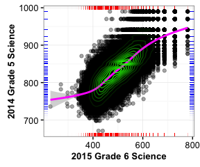

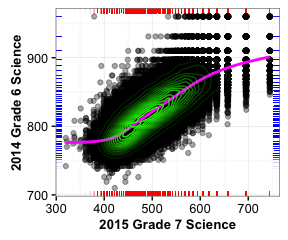

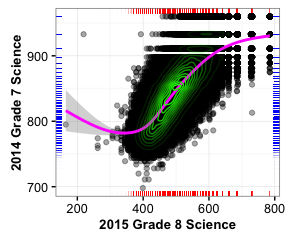